# VaR - wartość narażona na ryzyko

Karol Doliński

Informatyka i Ekonometria

# 1 Wprowadzenie

Celem niniejszej pracy jest oszacowanie wartości narażonej na ryzyko (ang. *Value at Risk*) w oparciu o wyestymowane wartości z modelu AR(1)-GARCH(1,1), a następnie ocena VaR pod względem poprawności wyznaczanych wartości za pomocą testów statystycznych.

Wykorzystane w pracy dane dotyczą okresu od 1 stycznia 2018 roku do 31 grudnia 2019 roku. Zbiór danych dotyczy śróddziennych notowań dla spółki Dino oraz jej dziennych notowań.

# 2 Model AR(1)-GARCH(1,1)

Pierwszym etapem badania było wyznaczenie zmienności zrealizowanej $\sigma_3^2$ wyrażonej wzorem:
$$\sigma_3^2 = (1 +
\frac{\sigma_{CO}^2}{\sigma_{OC}^2}) \sum_{i=1}^D{r^2_{t,i}},$$
gdzie:

- $\sigma_{CO}^2$ - wariancja stopy zwrotu pomiędzy kursem z zamknięcia, a kursem z otwarcia następnego dnia,
- $\sigma_{OC}^2$ - wariancja zwrotu dziennego (od otwarcia do zamknięcia),
- $r^2_{t,i}$ - śróddzienna stopa zwrotu z dnia $t$ z okresu $i$, gdzie $i = 1, 2, ..., D$.
- $D$ - liczba okresów na który można podzielić dzień sesji.

```r
df_intrady <- as_tibble(read.csv("DNP_intraday_2017_2020.csv", sep = ";"))
df_daily <- as_tibble(read.csv("dnp_d.csv"))

df_intrady <- df_intrady %>% select(day, hour, price)
df_intrady["datetime"] <- ymd_hms(paste(df_intrady$day, df_intrady$hour, sep = " "))

df_daily <- df_daily %>% select(day, open, close)
df_daily$day <- as_date(df_daily$day)

# filtering the required dates
df_intrady <- df_intrady %>% filter((minute(df_intrady$datetime) %% 10 == 0 & hour(df_intrady$datetime) < 17) | (hour(df_intrady$datetime) == 17 & minute(df_intrady$datetime) == 5))
df_intrady <- df_intrady %>% filter(year(df_intrady$datetime) %in% c(2018, 2019))

df_daily <- df_daily %>% filter(year(day) %in% c(2018, 2019))

# computing rates and filtering overnight rates
df_intrady["rate"] <- log(df_intrady$price / lag(df_intrady$price))
df_overnight <- df_intrady %>% filter(hour == "09:00:00") %>% na.omit()
df_intrady <- df_intrady %>% filter(hour != "09:00:00")

# computing sigma2
df_intrady = df_intrady %>% mutate(sigma2 = rate^2)

# computing sigma3
c <- var(df_overnight$rate) / var(log(df_daily$close / df_daily$open))
df_sum_sigma2 <- df_intrady %>% group_by(day) %>% summarise(sum_sigma2 = sum(sigma2))
df_daily["sigma3"] <- (1+c) * df_sum_sigma2$sum_sigma2
df_daily["sigma3_lag"] <- lag(df_daily$sigma3)
df_daily["rate"] <- log(df_daily$close / lag(df_daily$close))
df_daily <- na.omit(df_daily)
```

Następnie wyestymowano parametry modelu AR(1)-GARCH(1,1) z opóźnioną o jeden dzień wartością dziennej zmienności zrealizowanej $\sigma_3^2$ jako dodatkową zmienną objaśniającą w równaniu warunkowej wariancji, wykorzystując pierwsze 120 obserwacji (około 6 miesięcy). Dzięki temu możliwe było wyznaczenie prognozy warunkowej wartości oczekiwanej dziennej stopy zwrotu oraz jej warunkowej wariancji na jeden dzień do przodu. Tak zaprojektowane badanie powtarzano każdorazowo przesuwając o jeden dzień do przodu okno estymacji. W ten sposób wyznaczono prognozy warunkowych wartości oczekiwanych i warunkowych wariancji dla okresu około 18 miesięcy.

# 3 Model VaR

Na podstawie wyznaczonych prognoz z wykorzystaniem modelu AR(1)-GARCH(1,1) oszacowano wartość narażoną na ryzyko (VaR) w każdym dniu 18 miesięcznego okresu za pomocą funkcji `ugarchroll()` oraz korzystając z uproszczonej wersji, że dzienna stopa zwrotu spółki ma rozkład normalny z parametrami równymi prognozom uzyskanym dla danego dnia za pomocą modelu AR(1)-GARCH(1,1). Przy takim uproszczeniu wartość zagrożoną można wyznaczyć jako:

$$VaR_{t+1|t} =
1-e^{y_{t+1|t}z_\alpha\sqrt{h_{t+1|t}}},$$
gdzie:

- $y_{t+1|t}$ – prognoza warunkowej wartości oczekiwanej stopy zwrotu,
- $h_{t+1|t}$ – prognoza warunkowej wariancji,
- $z_\alpha$ – kwantyl odpowiadający prawdopodobieństwu $\alpha$ dla standardowego rozkładu normalnego.

VaR wyestymowany za pomocą funkcji `ugarchroll()` oznaczono jako *VaR I*, a ten wyznaczony w sposób uproszczony jako *VaR II*. Przyjęto poziom istotności równy 5%.

```r
# Method I
spec <- ugarchspec(variance.model = list(model = "sGARCH",
                                         garchOrder = c(1, 1),
                                         external.regressors = matrix(df_daily$sigma3_lag)),
                   mean.model = list(armaOrder = c(1, 0)),
                   distribution.model = "norm")

garch_roll <- ugarchroll(spec = spec,
                         data = df_daily$rate,
                         n.start = 120,
                         refit.every = 1,
                         refit.window = "moving",
                         solver = "hybrid",
                         calculate.VaR = TRUE,
                         VaR.alpha = 0.05,
                         keep.coef = TRUE)

VaR_prediction_I <- garch_roll@forecast$VaR$`alpha(5%)`

# Method II
VaR_prediction_II <- c()
for(i in 1:(nrow(df_daily)-120)){
  spec_i <- ugarchspec(variance.model = list(model = "sGARCH",
                                             garchOrder = c(1, 1),
                                             external.regressors = matrix(df_daily$sigma3_lag[i:(119+i)])),
                       mean.model = list(armaOrder = c(1, 0)),
                       distribution.model = "norm")

  garch_i <- ugarchfit(spec=spec_i, data=matrix(df_daily$rate[i:(119+i)]), solver = "hybrid")
  forecast_i <- ugarchforecast(fitORspec = garch_i, n.ahead = 1)

  h_p <- forecast_i@forecast$sigmaFor
  y_p <- forecast_i@forecast$seriesFor
  kwantyl <- qnorm(0.05,0,1,lower.tail = F)
  VaR_prediction_II[i] <- (1 - exp(y_p[1] + kwantyl*h_p[1]))
}
```

Wartości zagrożone wyznaczone dwiema metodami są do siebie dosyć zbliżone. Przez większość badanego okresu wartości *VaR I* są wyższe niż *VaR II*. Warto zauważyć, iż wartość narażona na ryzyko powinna być jak najbliższa stopie zwrotu jednocześnie będąc od niej mniejsza.

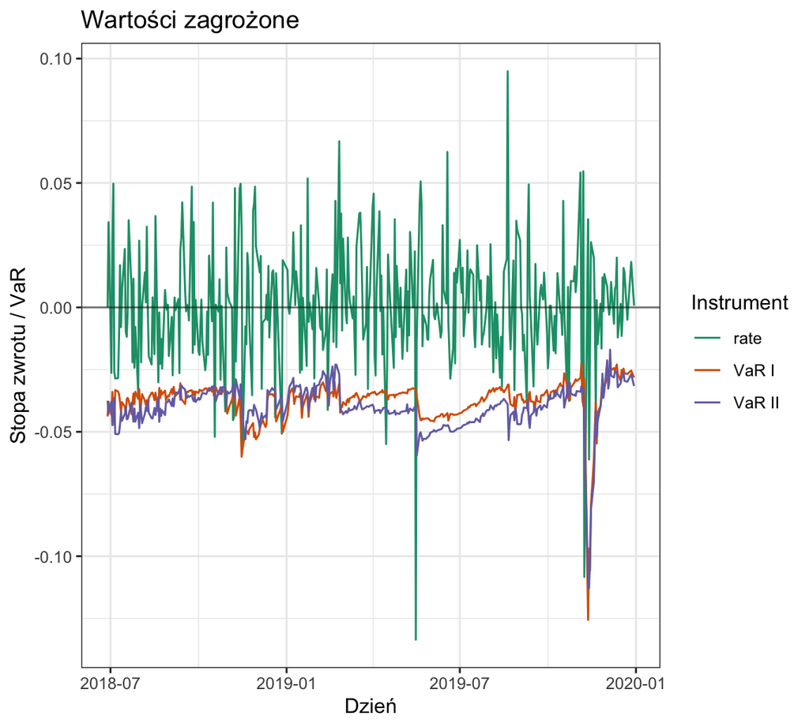

```r
df_results <- cbind.data.frame(df_daily$day[121:494], df_daily$rate[121:494], VaR_prediction_I, VaR_prediction_II)
colnames(df_results) <- c("day", "rate", "VaR I", "VaR II")

melt(df_results, id = "day") %>%
  ggplot(aes(x = day, y = value)) +
  geom_line(aes(color = variable)) +
  ggtitle("Wartości zagrożone") +
  xlab("Dzień") +
  ylab("Stopa zwrotu / VaR") +
  labs(color="Instrument") +
  geom_hline(yintercept=0, linetype="solid", color = "black", alpha=0.5) +
  theme_bw() +
  scale_color_brewer(palette="Dark2")
```

# 4 Ocena modelu VaR

Ocena trafności uzyskanych prognoz VaR została dokonana z wykorzystaniem dwóch testów statystycznych: testu Kupca i testu Christoffersena.

## 4.1 Test Kupca

Test Kupca weryfikuje, czy odsetek przekroczeń jest zgodny z przyjetym poziomem istotności. Hipoteza zerowa jest odrzucana zarówno w przypadku, gdy model niedoszacowuje, jak i wtedy, gdy model przeszacowuje ryzyko.

Zestaw hipotez:

$H_{0}$: VaR jest dobrze wyznaczony

$H_{1}$: VaR nie jest dobrze wyznaczony

## 4.2 Test Christoffersena

Test sprawdza czy przekroczenia wartości narażonej na ryzyko występują w próbie równomiernie (są niezależne w czasie). Jeśli nie, to znaczy, iż model przeszacowuje wartość narażoną na ryzyko w normalnych warunkach, natomiast niedoszacowuje jej w sytuacjach ekstremalnych, niestandardowych.

Zestaw hipotez:

$H_{0}$: przekroczenia VaR są niezależne w czasie

$H_{1}$: przekroczenia VaR nie są niezależne w czasie

## 4.3 Wyniki testów

Wyniki testów dla obu metod *VaR I* i *VaR II* są identyczne. Brak jest podstaw do odrzucenia hipotez głównych ponieważ p-value jest większe od 5%. Można stwierdzić, iż VaR jest dobrze wyznaczony oraz przekroczenia VaR są niezależne w czasie.

```r
df_test_results <- as.data.frame(matrix(NA, 2, 2))
colnames(df_test_results) <- c("VaR I", "VaR II")
rownames(df_test_results) <- c("Test Kupca", "Test Christoffersena")

df_test_results[1,1] <- VaRTest(alpha = 0.05, VaR = VaR_prediction_I, actual = df_results$rate)$uc.LRp
df_test_results[2,1] <- VaRTest(alpha = 0.05, VaR = VaR_prediction_I, actual = df_results$rate)$cc.LRp
df_test_results[1,2] <- VaRTest(alpha = 0.05, VaR = VaR_prediction_II, actual = df_results$rate)$uc.LRp
df_test_results[2,2] <- VaRTest(alpha = 0.05, VaR = VaR_prediction_II, actual = df_results$rate)$cc.LRp

df_test_results %>% kbl() %>% kable_styling() %>%
  footnote(general = "Tab. 1.: P-value dla testu Kupca i Christoffersena",
           general_title = "", footnote_as_chunk = T, title_format = c("italic"))
```

|  | VaR I | VaR II |
| --- | --- | --- |
| Test Kupca | 0.2440847 | 0.2440847 |
| Test Christoffersena | 0.4212228 | 0.4212228 |

Tab. 1.: P-value dla testu Kupca i Christoffersena

# 5 Podsumowanie

W pracy skutecznie wyznaczono VaR za pomocą dwóch metod wykorzystując model AR(1)-GARCH(1,1). Ponadto wyznaczono wartości zmienności zrealizowanej i uwzględniono je podczas estymacji modelu w równaniu warunkowej wariancji. Ocena obu podejść VaR za pomocą testów statystycznych wyszła identyczna, tzn. VaR został dobrze wyznaczony oraz jego przekroczenia były niezależne w czasie. Warto podkreślić, iż wartość narażona na ryzyko powinna być jak najbliższa stopie zwrotu jednocześnie będąc od niej mniejsza. Z uwagi na to, można by wskazać VaR I jako lepszy, ponieważ jest on częściej bliższy wartościom stopy zwrotu. Jednocześnie należy zaznaczyć, iż VaR nie jest odpowiednim narzędziem określania ryzyka, gdy występują zdarzenia ekstremalne.